# Analytics_201_S5

## Linear Regression with Severity Score

We can now look into using linear regression to identify the correlation between particular columns of quantitative data in our dataframe.

```r
linreg = lm(severity ~ sub_gender + sub_race + hour + district, data)
sm <- summary(linreg)
sm ## Printing summary table
```

```
##
## Call:
## lm(formula = severity ~ sub_gender + sub_race + hour + district,
##     data = data)
##
## Residuals:
##    Min     1Q Median     3Q    Max
## -4.943 -1.998 -1.259  2.674  5.828
##
## Coefficients:
##                   Estimate Std. Error t value Pr(>|t|)
## (Intercept)       5.726026   0.106195  53.920  < 2e-16 ***
## sub_genderMALE   -0.698549   0.081330  -8.589  < 2e-16 ***
## sub_raceHISPANIC  0.097524   0.069167   1.410 0.158577
## sub_raceWHITE     0.330997   0.097538   3.394 0.000693 ***
## hour             -0.037301   0.004070  -9.165  < 2e-16 ***
## district          0.002482   0.003964   0.626 0.531234
## ---
## Signif. codes:  0 '***' 0.001 '**' 0.01 '*' 0.05 '.' 0.1 ' ' 1
##
## Residual standard error: 2.771 on 9923 degrees of freedom
## Multiple R-squared:  0.01819,    Adjusted R-squared:  0.01769
## F-statistic: 36.76 on 5 and 9923 DF,  p-value: < 2.2e-16
```

```r
m <- mean(sm$residuals^2)
m # This metric is called the Mean Squared Error (MSE) - this represents the variance of the errors
```

```
## [1] 7.672761
```

```r
sqrt(m) # This metric is called the Root Mean Square Error (RMSE) - this represents the standard deviation of the errors
```

```
## [1] 2.769975
```

```r
linreg2 = lm(severity ~ district, data)
summary(linreg2)
```

```
##
## Call:
## lm(formula = severity ~ district, data = data)
##
## Residuals:
##    Min     1Q Median     3Q    Max
## -3.771 -1.722 -1.603  3.229  5.397
##
## Coefficients:
##             Estimate Std. Error t value Pr(>|t|)
## (Intercept) 4.595573   0.054463  84.380   <2e-16 ***
## district    0.007015   0.003873   1.811   0.0701 .
## ---
## Signif. codes:  0 '***' 0.001 '**' 0.01 '*' 0.05 '.' 0.1 ' ' 1
##
## Residual standard error: 2.795 on 9927 degrees of freedom
## Multiple R-squared:  0.0003304,  Adjusted R-squared:  0.0002297
## F-statistic: 3.281 on 1 and 9927 DF,  p-value: 0.07012
```

```r
linreg3 = lm(severity ~ hour, data)
summary(linreg3)
```

```
##
## Call:
## lm(formula = severity ~ hour, data = data)
##
## Residuals:
##    Min     1Q Median     3Q    Max
## -4.233 -1.920 -1.333  2.806  5.668
##
## Coefficients:
##              Estimate Std. Error t value Pr(>|t|)
## (Intercept)  5.233121   0.063980  81.793   <2e-16 ***
## hour        -0.039157   0.004076  -9.607   <2e-16 ***
## ---
## Signif. codes:  0 '***' 0.001 '**' 0.01 '*' 0.05 '.' 0.1 ' ' 1
##
## Residual standard error: 2.783 on 9927 degrees of freedom
## Multiple R-squared:  0.009211,   Adjusted R-squared:  0.009111
## F-statistic: 92.29 on 1 and 9927 DF,  p-value: < 2.2e-16
```

We can view our findings along with plots of hour/district vs severity.

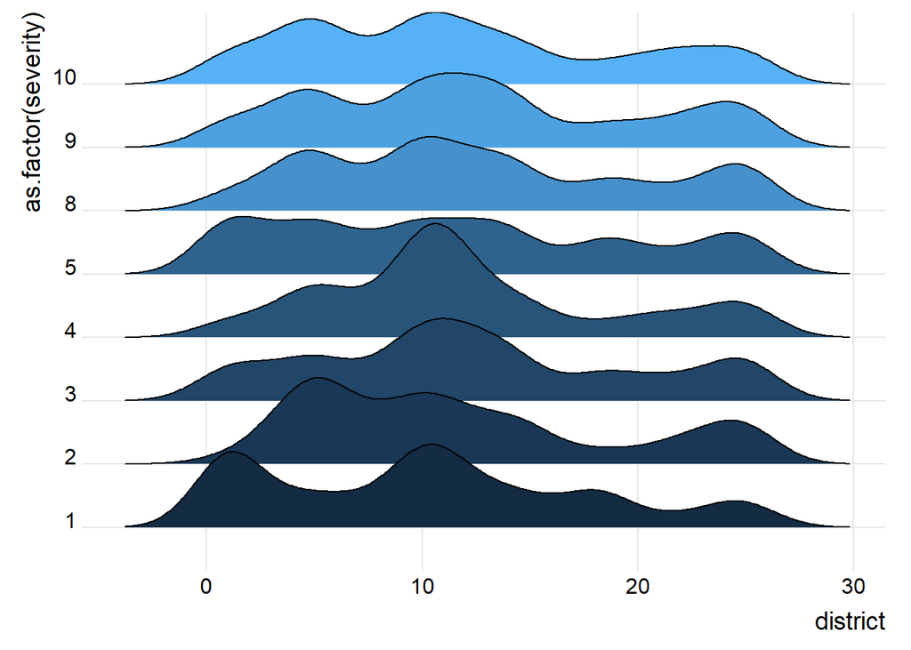

```r
library(ggplot2)
library(ggridges)
ggplot(data, aes(x = district, y = as.factor(severity), fill = severity)) +
  geom_density_ridges() +
  theme_ridges() +
  theme(legend.position = "none")
```

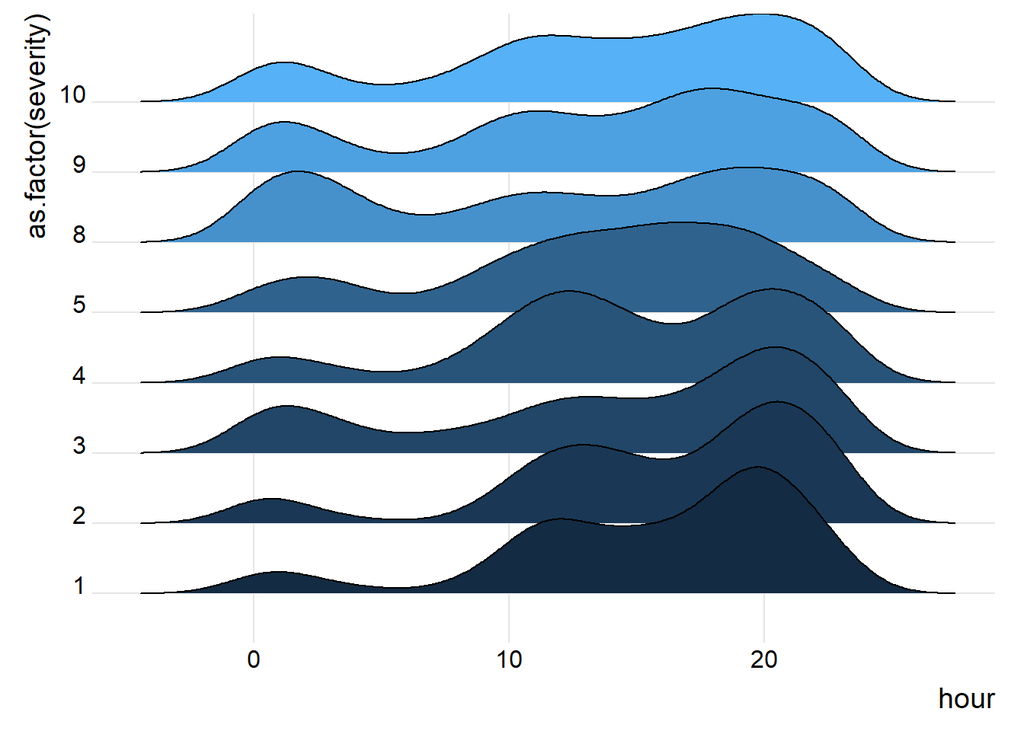

```r
ggplot(data, aes(x = hour, y = as.factor(severity), fill = severity)) +
  geom_density_ridges() +
  theme_ridges() +
  theme(legend.position = "none")
```

## Decision Tree

All right, time for some exciting machine learning algorithms. Decision tree is like a flowchart. You start with the entire dataset and ask a question. Depending on the answer, your data has now been separated into multiple subgroups called “nodes.” At each node you ask another question. Naturally, that’s how the tree branches out.

Let’s see this in action. As usual, begin by installing the relevant package, *rpart*.

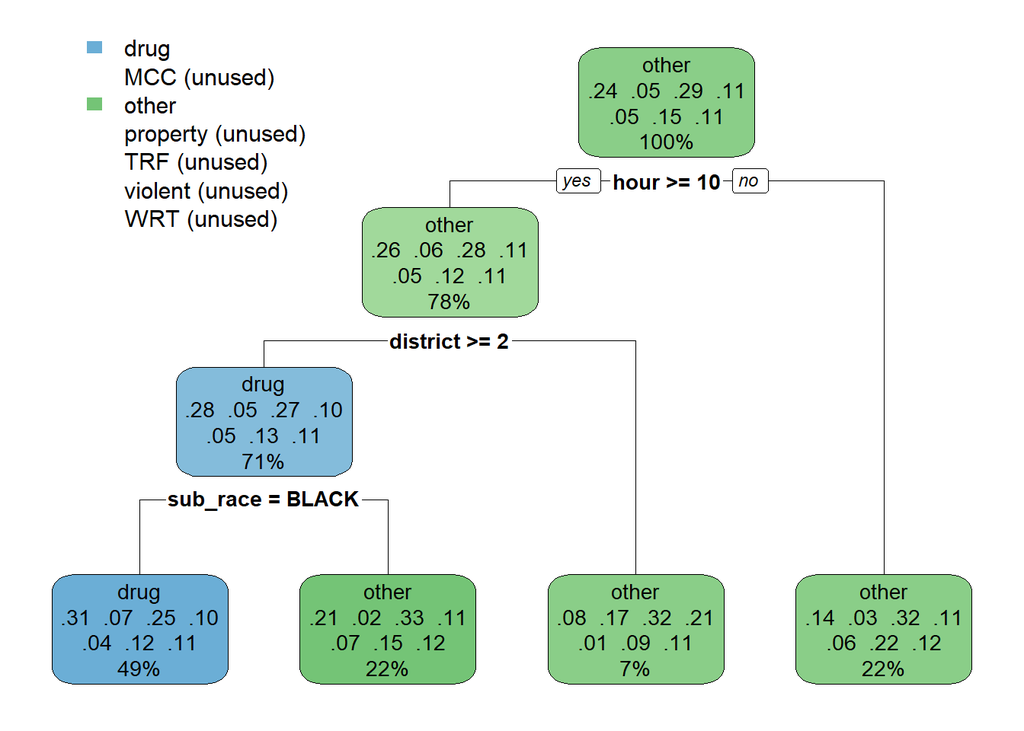

```r
library(rpart)
library(rpart.plot)
# A simple tree
tree_model <- rpart(crime_code ~ sub_gender + sub_race + hour + district, data)

rpart.plot(tree_model)
```

## Random Forest

You have a tree. You have another tree. In fact, you have many trees. What do you *really* have? That’s right, you have a forest.

Random forest ia a method of aggregating (or “ensembling,” as the lingo goes) multiple decision trees. The broad idea is that two heads are better than one, and the same goes for trees.

First things first: Be sure to install the *ranger* package.

```r
library(ranger)
forest <- ranger(crime_code ~ sub_gender + sub_race + hour + district,
                 data,
                 importance='impurity')
print(forest)
```

```
## Ranger result
##
## Call:
##  ranger(crime_code ~ sub_gender + sub_race + hour + district,      data, importance = "impurity")
##
## Type:                             Classification
## Number of trees:                  500
## Sample size:                      9929
## Number of independent variables:  4
## Mtry:                             2
## Target node size:                 1
## Variable importance mode:         impurity
## Splitrule:                        gini
## OOB prediction error:             65.34 %
```

```r
# What else can we learn about our forest?
names(forest)
```

```
##  [1] "predictions"               "num.trees"
##  [3] "num.independent.variables" "mtry"
##  [5] "min.node.size"             "variable.importance"
##  [7] "prediction.error"          "forest"
##  [9] "confusion.matrix"          "splitrule"
## [11] "treetype"                  "call"
## [13] "importance.mode"           "num.samples"
## [15] "replace"
```

```r
# Check out feature importance
forest$variable.importance
```

```
## sub_gender   sub_race       hour   district
##   87.74943  117.12344  453.39007  504.46183
```

The purpose of the “importance” call above is to allow us to determine which independent/predictor variables had the most influence on the outcome.

What does a random forest model look like? We would love to show a diagram like we did with decision trees, but 500 trees are a bit too many to plot. So instead, we will conclude with a smoothing picture of a real forest.

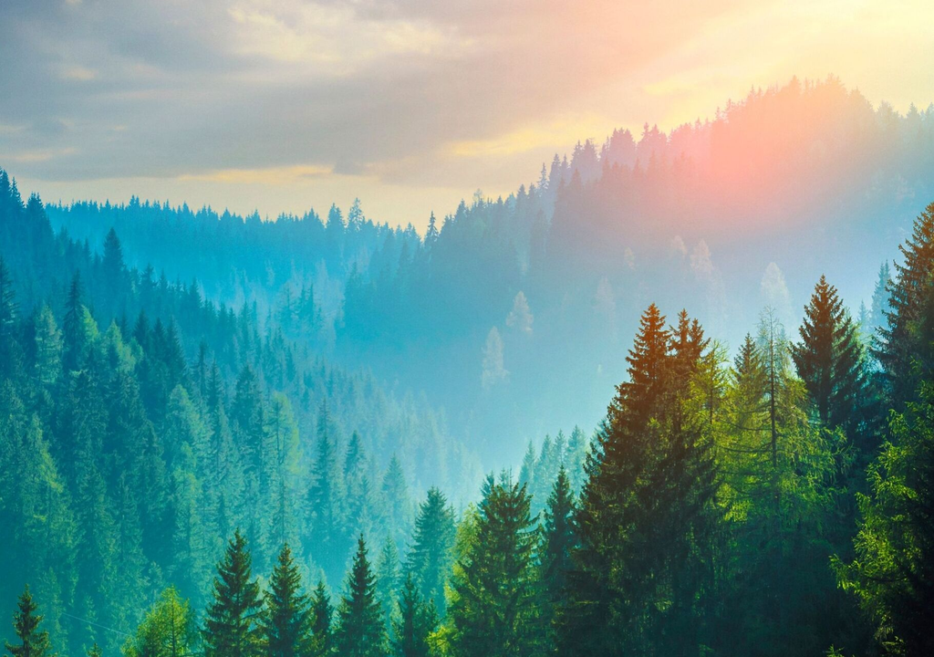